# Assignment 3

#### **Instructor: Prof. Gunnar Heins**

#### **Teaching Assistant: Pedro de Sousa Almeida**

#### Student: C.H.(Chenhui Lu)

#### UFID: 76982846

===============================================================================

```r
# Empty Environment
rm(list = ls())
library("data.table")
#library
library("data.table")
library(stargazer)
library("AER")
```

```r
library(ggplot2)
```

### **1 Working with Datasets (40 points)**

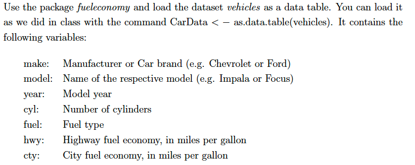

```r
knitr::include_graphics("/Users/terrylu/Desktop/UF/fall/R and Matlab/R/Assgnments/Git/UF-ECO-7938/3/Pic/1.png")
```

```r
library(fueleconomy)
CarData <- as.data.table(vehicles)
```

#### 1. Plot the total number of car models over time (use either plot() or ggplot2)

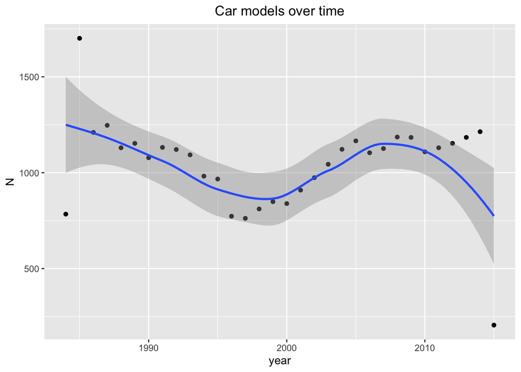

```r
model_no <- CarData[, .N, by = year]    #make a set of x = year, y = number
ggplot(model_no, aes(year, N)) + geom_point() + ggtitle("Car models over time") + theme(plot.title = element_text(hjust = 0.5)) + geom_smooth()                                  #ggplot
```

#### 2. Plot the average fuel effciency on highways, hwy, over time. What do you find?

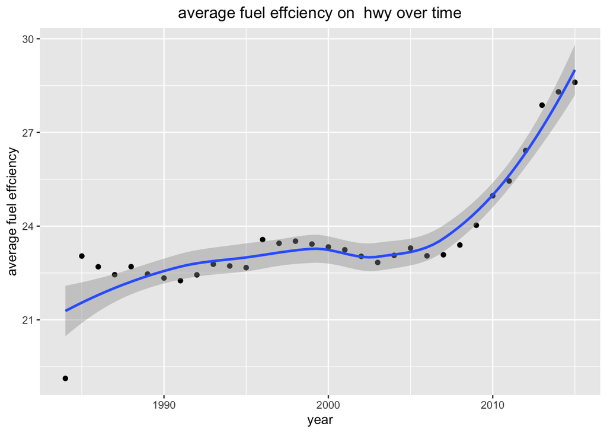

```r
av_hwy <- CarData[, mean(hwy), by = year]       #make a set with x = year, y = mean
P2 <- ggplot(av_hwy,aes(year, V1)) + geom_point()   #ggplot
P2 + labs(title = "average fuel effciency on  hwy over time", x = "year", y ="average fuel effciency") + theme(plot.title = element_text(hjust = 0.5)) + geom_smooth()  # edit the labels
```

The chart shows that the average fuel effcicency on highways remained stable for a period but shows a significant increase after around 2007, potentially due to technological improvements.

#### 3.Keep only those car brands that have at least 1000 observations in the dataset over allyears.

```r
make_over <- CarData[, if(.N >= 1000) .SD, by = make]     # only thodr make's number >= 1000
make_over[, .SD[1], by = make]$make         # only keep one subset of the same make and show the name
```

```
## [1] "BMW"           "Chevrolet"     "Dodge"         "Ford"
## [5] "GMC"           "Mercedes-Benz" "Nissan"        "Toyota"
```

#### 4.Regress hwy on make and cty without a constant. What does this tell you about the fuel effciency of each brand?

```r
reg_1 <- lm(hwy ~ 0 + make + cty ,data = make_over) #regression without the constant
summary(reg_1)
```

```
##
## Call:
## lm(formula = hwy ~ 0 + make + cty, data = make_over)
##
## Residuals:
##     Min      1Q  Median      3Q     Max
## -38.249  -1.338  -0.077   1.325  12.702
##
## Coefficients:
##                   Estimate Std. Error t value Pr(>|t|)
## makeBMW           6.866701   0.085399   80.41   <2e-16 ***
## makeChevrolet     4.897728   0.069618   70.35   <2e-16 ***
## makeDodge         4.314012   0.071855   60.04   <2e-16 ***
## makeFord          4.437854   0.072430   61.27   <2e-16 ***
## makeGMC           3.845235   0.070150   54.81   <2e-16 ***
## makeMercedes-Benz 5.454751   0.089113   61.21   <2e-16 ***
## makeNissan        4.560725   0.093946   48.55   <2e-16 ***
## makeToyota        4.045984   0.089328   45.29   <2e-16 ***
## cty               1.051851   0.003583  293.55   <2e-16 ***
## ---
## Signif. codes:  0 '***' 0.001 '**' 0.01 '*' 0.05 '.' 0.1 ' ' 1
##
## Residual standard error: 2.274 on 16264 degrees of freedom
## Multiple R-squared:   0.99,  Adjusted R-squared:   0.99
## F-statistic: 1.783e+05 on 9 and 16264 DF,  p-value: < 2.2e-16
```

1. The coefficients of make actually present their fuel efficiency compared with other brands. For instance, the BMW is the mots fuel efficient brand, and compared with Toyota, BMW can drive 2.82 miles more than Toyota.
2. The city fuel economy positive affects the hwy, 1 unit cty higher, 1.05 unit hwy higher.

#### 5. Run the same regression as in Part (4), but include a constant this time. How do you interpret your estimate of this constant? How does it relate to your findings in Part (4)?

```r
reg_2 <- lm(hwy ~ make + cty ,data = make_over)   #regression with the constant
summary(reg_2)
```

```
##
## Call:
## lm(formula = hwy ~ make + cty, data = make_over)
##
## Residuals:
##     Min      1Q  Median      3Q     Max
## -38.249  -1.338  -0.077   1.325  12.702
##
## Coefficients:
##                    Estimate Std. Error t value Pr(>|t|)
## (Intercept)        6.866701   0.085399   80.41   <2e-16 ***
## makeChevrolet     -1.968972   0.072138  -27.30   <2e-16 ***
## makeDodge         -2.552689   0.077045  -33.13   <2e-16 ***
## makeFord          -2.428846   0.074501  -32.60   <2e-16 ***
## makeGMC           -3.021466   0.077855  -38.81   <2e-16 ***
## makeMercedes-Benz -1.411949   0.092056  -15.34   <2e-16 ***
## makeNissan        -2.305976   0.090167  -25.57   <2e-16 ***
## makeToyota        -2.820717   0.082551  -34.17   <2e-16 ***
## cty                1.051851   0.003583  293.55   <2e-16 ***
## ---
## Signif. codes:  0 '***' 0.001 '**' 0.01 '*' 0.05 '.' 0.1 ' ' 1
##
## Residual standard error: 2.274 on 16264 degrees of freedom
## Multiple R-squared:  0.8563, Adjusted R-squared:  0.8563
## F-statistic: 1.212e+04 on 8 and 16264 DF,  p-value: < 2.2e-16
```

After adding the intercept, the intercept is 6.87, representing the baseline value of highway fuel efficiency (hwy). In this case, BMW becomes the implicit baseline for the hwy standard. We can see that the coefficient for Toyota is -2.82, indicating that it travels 2.82 miles less per gallon compared to the reference brand (BMW in this case), which is consistent with the result we obtained in Part (4). And the coefficient of cty is the same, which certify our inpretation.

#### 6. For each car maker (make), compute the average fuel efficiency on highways in year 1990 and 2010, respectively, and use these values to compute the percentage change in fuel efficiency for each manufacturer between these 2 periods. State the 3 companies which achieved the largest increases in fuel efficiency during this time.

```r
CarData[, mean := mean(hwy), by = .(make,year)]          #generage the variable of mean by every make each year
make_1990 <- CarData[year == 1990, .(make, mean)]        #spilt the data to 2 sets of only 1990 and 2010， only keep the make and mean variables
make_2010 <- CarData[year == 2010, .(make, mean)]
make_1990 <- make_1990[, .SD[1], by = make]              #only keep 1 for every make
make_2010 <- make_2010[, .SD[1], by = make]
make_com <- merge(make_1990, make_2010, by = "make")     #merge the 2 sets by make
make_com <- make_com[, increase := (mean.y - mean.x)/mean.x]      #generage the variable of incerase by deduction
setorder(make_com, -increase)                            #set the inverse order by "increase" variable
make_com[1:3]$make                                       #show the resulet of biggest 3
```

```
## [1] "Rolls-Royce" "Lamborghini" "Jaguar"
```

### **2 Writing Loops and Functions (20 points)**

#### 1. (8 points) Suppose you have a vector x. Write a function that gives out the maximum out of all elements of x that are smaller than 5. If no element is smaller than 5, it should return 0.

```r
Bigger5 <- function(x){          # set up the function
  t <-  0                        # set up the loop factor
for (i in 1:length(x)) {         # set up the loop
  if (x[i] < 5) {                # set up the first if
    if (x[i] > t) {              # set up the second if
      t <- x[i]                  # if x[i] < 5 and x[i] bigger than x[i-1], make it as t
    }
  }
}
t                                # output the t
}
```

Example Test:

```r
x1 <- c(3, 4, 5, 2, 5, 4, 2, 1, 4.999)
Bigger5(x1)
```

```
## [1] 4.999
```

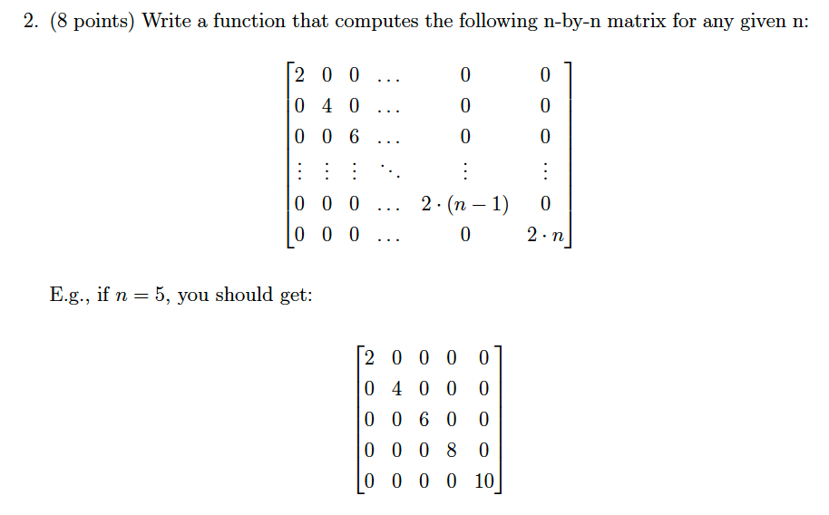

```r
knitr::include_graphics("/Users/terrylu/Desktop/UF/fall/R and Matlab/R/Assgnments/Git/UF-ECO-7938/3/Pic/2.2.png")
```

```r
nnmetrix <- function(x,n){                 # set up the function with 2 input x:matrix, n: dimention
  z <- matrix(nrow = n, ncol = n)          # set up a empty n*n metrix
for (i in 1:n) {                           # set up tht 1st loop
  for (j in 1:n) {                         # 2nd loop, to achieve every z_ij
     z[i,j] <- x[i,j]                      # replace the z_ij with x_ij
  }
}
z                                          # output
}
```

Example: set up a uniform random metrix to test.

```r
set.seed(123)                    # set up a random seed
random_matrix <- matrix(runif(400, min = 0, max = 1), nrow = 20, ncol = 20)   #set up the 20*20 metrix randomly

nnmetrix(random_matrix, 6)       # run the function using n = 6
```

```
##           [,1]      [,2]      [,3]       [,4]      [,5]      [,6]
## [1,] 0.2875775 0.8895393 0.1428000 0.66511519 0.2436195 0.5999890
## [2,] 0.7883051 0.6928034 0.4145463 0.09484066 0.6680556 0.3328235
## [3,] 0.4089769 0.6405068 0.4137243 0.38396964 0.4176468 0.4886130
## [4,] 0.8830174 0.9942698 0.3688455 0.27438364 0.7881958 0.9544738
## [5,] 0.9404673 0.6557058 0.1524447 0.81464004 0.1028646 0.4829024
## [6,] 0.0455565 0.7085305 0.1388061 0.44851634 0.4348927 0.8903502
```

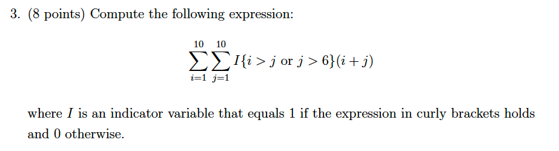

```r
knitr::include_graphics("/Users/terrylu/Desktop/UF/fall/R and Matlab/R/Assgnments/Git/UF-ECO-7938/3/Pic/2.3.png")
```

```r
t <- 0                                      # set up the initial outer sum value
for (i in 1:10) {                           # set up the outer sum loop
  z <- 0                                    # set up the initial inner sum value
  for (j in 1:10) {                         # set uo the inner sum loop
    I <- ifelse(i > j | j > 6 , 1, 0)       # set up the value function of I, with ifelse function
    z <- z + I *(i + j)                     # calculation the sum of inner loop
  }
  t <- t + z                                # calculate the sum of outer loop (total sum)
}
t                                           # output
```

```
## [1] 953
```

#### **3.Crime and Gun Laws [40 points]**

A large literature in Economics and beyond has tried to answer the question of how the availability of guns affects crime. Many papers have for example used the introduction of “shall-issue laws” in many states to answer this question which made it substantially easier to get a permit to carry a gun. Did these laws result in reductions of crime over time?

###Data: To test this (and to practice regressions), the package “AER” has a data set on gun laws and crime by state. To get the data load the package AER and run:

```r
# Empty Environment
rm(list = ls())
```

```r
library("AER")
data("Guns")
data <- as.data.table(Guns)
```

###Main Variables of interest: violent: Violent crime rate (incidents per 100,000 members of the population) law: Does the state have a shall-carry law in effect in that year?

###Questions:

###1. Sort states according to the worst rate of violent crime in 1999

```r
setorder(data, -violent)
head(data)
```

```
##      year violent murder robbery prisoners     afam     cauc     male
##    <fctr>   <num>  <num>   <num>     <int>    <num>    <num>    <num>
## 1:   1993  2921.8   78.5  1229.6      1287 22.92985 25.70434 14.05723
## 2:   1992  2832.8   75.2  1266.4      1221 23.30794 25.40950 14.55931
## 3:   1994  2662.6   70.0  1107.2      1549 22.56992 26.08649 13.63920
## 4:   1995  2661.4   65.0  1239.0      1782 22.26011 26.44189 13.29450
## 5:   1996  2469.8   73.1  1186.7      1650 21.94686 27.00581 12.88547
## 6:   1990  2458.2   77.8  1213.5      1132 23.41714 26.08502 15.29709
##    population   income  density                state    law
##         <num>    <num>    <num>               <fctr> <fctr>
## 1:   0.576358 21817.18 9.448492 District of Columbia     no
## 2:   0.584183 21309.23 9.576771 District of Columbia     no
## 3:   0.564982 22003.30 9.262000 District of Columbia     no
## 4:   0.551273 21611.43 9.037263 District of Columbia     no
## 5:   0.538273 21844.64 8.824147 District of Columbia     no
## 6:   0.603814 20289.77 9.898590 District of Columbia     no
```

###2. Compute and plot the average rate of violent crime over all U.S. states over time.Compare it with the time series for New York State and Alaska.

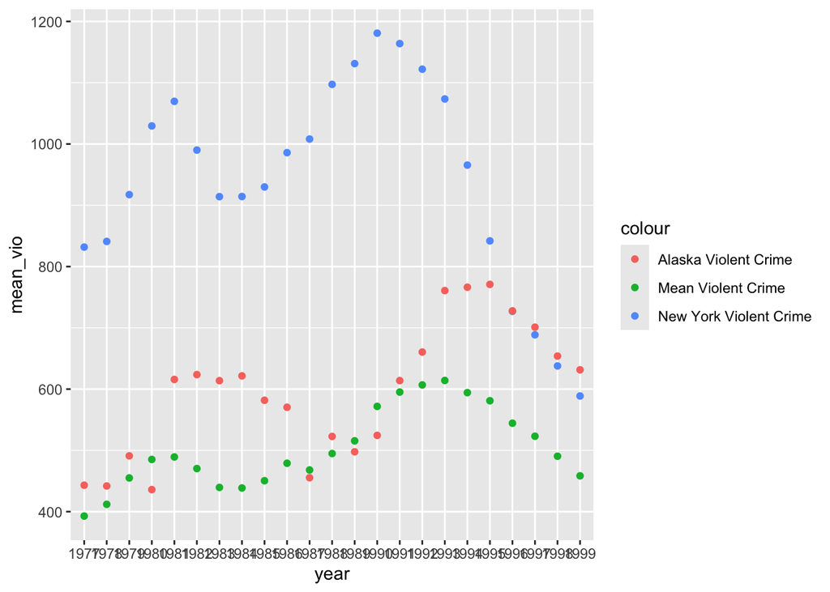

```r
data <- data[, mean_vio := mean(violent), by = year]                      # generate the variable of mean (average)
data_us <- data[, .SD[1], by = year][, .(year, mean_vio)]                 # generate the data set contains us average violent rate by year, only keep the first in each year, only keep variables of year, violent, (more clear)
data_ny <- data[state == "New York",.(year, violent)]                     # generate the data set contains NY violent rate and year
data_als <- data[state == "Alaska",.(year, violent)]                      # generate the data set contains Alaska violent rate and year
data_com <- merge(data_us, data_ny, by = "year")                          # merge the 3 data set by "year" with 2 steps !
data_com <- merge(data_com, data_als, by = "year")

ggplot() +                                                                                        # ggplot in a chart
  geom_point(data = data_com, aes(x = year, y = mean_vio, color = "Mean Violent Crime")) +        # ggplot us' data set by year
  geom_point(data = data_com, aes(x = year, y = violent.x, color = "New York Violent Crime")) +   # ggplot ny's data set by year
  geom_point(data = data_com, aes(x = year, y = violent.y, color = "Alaska Violent Crime")) +     # ggplot als' data set by year
  geom_smooth()
```

As the picture shown, the violent crime rate in the NYC is highest, followed by Alaska violent crime rate. Both of them higher than the average US violent crime rate with the majority of years.

###3. Run a regression of the rate of violent crime on the law. What do you find?

```r
reg <- lm(violent ~ law, data = data)
summary(reg)
```

```
##
## Call:
## lm(formula = violent ~ law, data = data)
##
## Residuals:
##     Min      1Q  Median      3Q     Max
## -495.24 -228.84  -63.64  134.06 2379.56
##
## Coefficients:
##             Estimate Std. Error t value Pr(>|t|)
## (Intercept)   542.24      10.98  49.386  < 2e-16 ***
## lawyes       -161.19      22.27  -7.236 8.32e-13 ***
## ---
## Signif. codes:  0 '***' 0.001 '**' 0.01 '*' 0.05 '.' 0.1 ' ' 1
##
## Residual standard error: 327.2 on 1171 degrees of freedom
## Multiple R-squared:  0.0428, Adjusted R-squared:  0.04199
## F-statistic: 52.36 on 1 and 1171 DF,  p-value: 8.319e-13
```

The exists of law negatively affect the violent crime rate significantly with the coefficient of -161.19. The exists of this law can decrease 161.19 of the violent crime rate (per 100,000 members of the population) compared with the case without this law.

The R-squared and Adjusted R-squared value is relatively low, indicating that the model does not has a good fit.